# Evolution of repetitive sequences in viruses

Author

Kasun Bebarende Guruge

# Abstract

This project investigates the evolution of viral genomes. Using genomic data from various viruses, including coronaviruses and others such as HIV, adenovirus, Ebola, and Hepatitis B, we implement algorithms to calculate pairwise Hamming distances, construct rooted phylogenetic trees, and reconstruct ancestral sequences. Visualizations of phylogenetic trees and ancestral sequence reconstructions highlight key evolutionary events.

# Introduction

In this project, we aim to study the evolution of various viruses. By analyzing genomic sequences from coronaviruses and other viral families, we investigate conserved patterns and evolutionary relationships that shed light on their functional significance.

This work employs computational approaches to address fundamental questions about viral evolution, laying the groundwork for deeper exploration of the role of repetitive sequences in genomic stability, adaptability, and pathogenicity.

# Data Structures and Algorithms

## Frequent K-mers Analysis

### Data Structures

- **Dictionary (`frequency_map`)**:
  - **Purpose**: Stores k-mers as keys and their counts as values.
  - **Structure**: `{k-mer: count}`
  - **Example**: `{"ATG": 3, "TGC": 2}`.

### Algorithms

- **Frequency Mapping**:
  - Iterates through the sequence to extract all possible k-mers and updates their counts in `frequency_map`.
  - **Complexity**: (O(n k)), where (n) is the length of the sequence and (k) is the k-mer size.
- **Most Frequent K-mers**:
  - Identifies the k-mer(s) with the highest count from `frequency_map`.
  - **Complexity**: (O(m)), where (m) is the number of unique k-mers.

## PolyA Tail Trimming

### Data Structures

- **String (`sequence`)**:
  - Represents the DNA/RNA sequence to be analyzed.

### Algorithms

- **Trimming**:
  - Removes trailing ‘A’ characters using the `rstrip` method.
  - **Complexity**: (O(n)), where (n) is the length of the sequence.

## Hamming Distance Calculation

### Data Structures

- **Strings (`seq1`, `seq2`)**:
  - Represent two sequences of equal length to compare.
- **Integer (`distance`)**:
  - Accumulates the count of mismatched positions.

### Algorithms

- **Pairwise Comparison**:
  - Iterates through the characters of the two sequences, incrementing `distance` for mismatches.
  - **Complexity**: (O(n)), where (n) is the sequence length.

## Distance Matrix Construction

### Data Structures

- **List of Strings (`names`)**:
  - Stores the names of the sequences.
- **2D List (`distance_matrix`)**:
  - A symmetric matrix that stores Hamming distances between sequence pairs.

### Algorithms

- **Nested Loop Comparison**:
  - Computes the Hamming distance for each pair of sequences and populates the matrix.
  - **Complexity**: (O(m^2 n)), where (m) is the number of sequences and (n) is the sequence length.

## Phylogenetic Tree Construction

### Data Structures

- **List (`lower_triangular`)**:
  - Stores the lower triangular form of the distance matrix for tree-building.
- **DistanceMatrix (`dm`)**:
  - Biopython’s `DistanceMatrix` class encapsulates the sequence names and distances.
- **Tree (`tree`)**:
  - Represents the phylogenetic tree in Newick format.

### Algorithms

- **Neighbor Joining (NJ)**:
  - Constructs a phylogenetic tree using the distance matrix.
  - **Complexity**: (O(m^3)), where (m) is the number of sequences.
- **Midpoint Rooting**:
  - Sets the tree’s root at the midpoint for better visualization.
  - **Complexity**: (O(m)).

## Tree Visualization

### Data Structures

- **TreeStyle (`ts`)**:
  - Configures the visual style of the tree.
- **TextFace**:
  - Adds text labels to internal nodes.

### Algorithms

- **Tree Rendering**:
  - Traverses the tree and assigns labels or custom styles to nodes.
  - **Complexity**: (O(m)), where (m) is the number of nodes.

## Small Parsimony Algorithm

### Data Structures

- **Dictionary (`scores`)**:
  - Stores the cost matrix for each node at each sequence position.
  - **Structure**: `{node: [{base: cost}]}`.
- **Dictionary (`tags`)**:
  - Tracks whether a node’s score is computed (1 for computed, 0 otherwise).
- **List (`alphabet`)**:
  - Represents possible bases (e.g., `['A', 'C', 'G', 'T']`).

### Algorithms

- **Dynamic Programming**:
  - For internal nodes, computes the minimum cost for each base by combining the scores of child nodes.
  - **Complexity**: (O(n m b^2)), where (n) is the sequence length, (m) is the number of nodes, and (b) is the size of the alphabet (4 for DNA).
- **Sequence Reconstruction**:
  - Backtracks to infer the most parsimonious sequence for each internal node.
  - **Complexity**: (O(n m)).

## Sequence Downloading

### Data Structures

- **Dictionary (`sequences`)**:
  - Maps sequence names to their nucleotide sequences.
  - **Structure**: `{name: sequence}`.

### Algorithms

- **API Request**:
  - Fetches genome data from NCBI using HTTP requests.
  - **Complexity**: Dependent on API latency.

## Summary of Core Functionalities

| **Task** | **Data Structures** | **Algorithm** | **Complexity** |
| --- | --- | --- | --- |
| Frequent k-mer Analysis | Dictionary | Sliding window | (O(n k)) |
| PolyA Tail Trimming | String | Trimming | (O(n)) |
| Hamming Distance | Strings, Integer | Pairwise Comparison | (O(n)) |
| Distance Matrix | List, 2D List | Nested Loops | (O(m^2 n)) |
| Phylogenetic Tree | List, DistanceMatrix, Tree | Neighbor Joining | (O(m^3)) |
| Visualization | TreeStyle, TextFace | Tree Rendering | (O(m)) |
| Small Parsimony Algorithm | Dictionary, List | Dynamic Programming | (O(n m b^2)) |
| Sequence Downloading | Dictionary | HTTP Requests | Dependent on network speed |

### How to compile?

#### How to Run the Quarto File

To render the Quarto file and generate an HTML output from the `.qmd` file that contains your Python code, follow these steps:

1. **Install Quarto**: First, make sure you have Quarto installed. You can download and install it from the official website: https://quarto.org. After installation, you can check if it’s installed by running:

   ```
   quarto --version
   ```

2. Navigate to the directory containing your .qmd file: Open your terminal and navigate to the folder where your .qmd file is located:

```
   cd /path/to/your/quarto/file
```

3. Render the Quarto file: Use the quarto render command to convert your .qmd file into an HTML document:

```
   quarto render p3.qmd
```

This will execute any Python code in the document, and Quarto will create an HTML output (by default). The output file will be saved in the same directory with the .html extension.

4. View the rendered HTML file: After rendering, you can open the generated HTML file in your browser:

```
    open p3.html  # On MacOS
    xdg-open p3.html  # On Linux
    start p3.html  # On Windows
```

#### How to run the Python files

#### **Using Shell Commands**

If you’re working with Quarto in a terminal-based setup, you can use shell commands to run Python files and integrate outputs:

```
python task1.py
python task2.py
python task3.py
python task4.py
python taskE1.py
```

# Results

## Task 4

### Phylogenetic tree

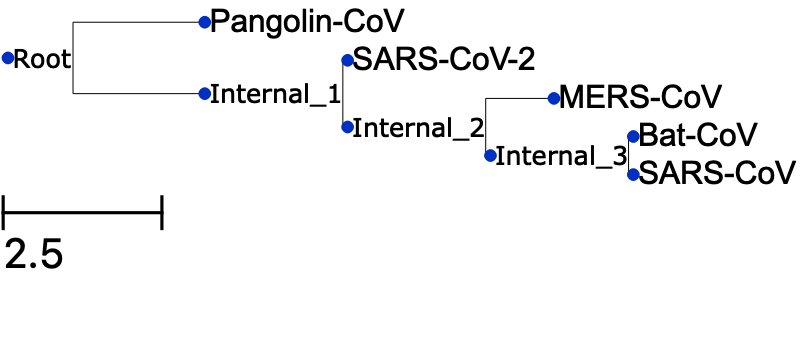

### Ancestral Sequences, Distance Matrix and Runtimes

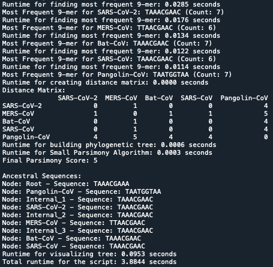

## Task E1

### Phylogenetic tree

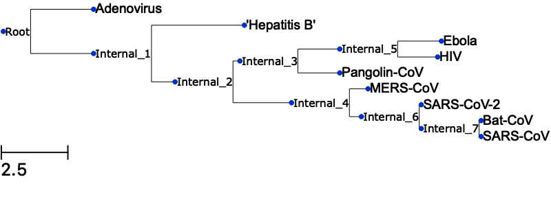

### Ancestral Sequences, Distance Matrix and Runtimes

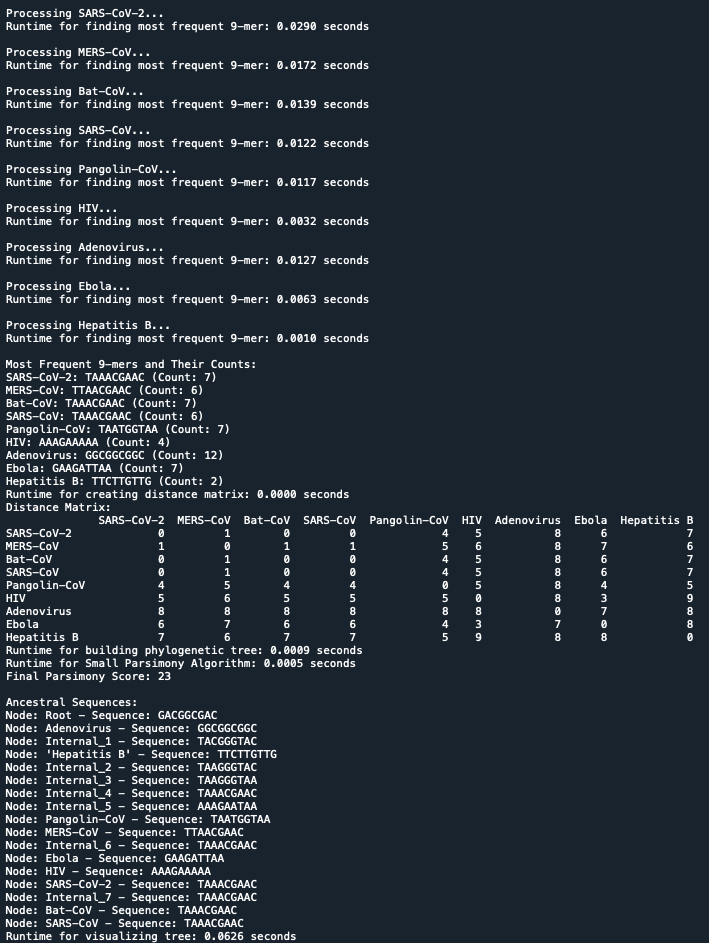

[output not shown]

### References for Imported Packages

- **BioPython (`SeqIO` and `DistanceTreeConstructor`)**  
  Cock, P. J. A., Antao, T., Chang, J. T., Chapman, B. A., Cox, C. J., Dalke, A., & Friedberg, I. (2009). Biopython: Freely available Python tools for computational molecular biology and bioinformatics. *Bioinformatics*, 25(11), 1422–1423. https://doi.org/10.1093/bioinformatics/btp163
- **ETE3 (`Tree`, `TreeStyle`, and `TextFace`)**  
  Huerta-Cepas, J., Serra, F., & Bork, P. (2016). ETE 3: Reconstruction, analysis, and visualization of phylogenomic data. *Molecular Biology and Evolution*, 33(6), 1635–1638. https://doi.org/10.1093/molbev/msw046